# Effect of User Reviews on Readers’ Perceptions of a Short Story

W241 Final Project Experiment

Jack Workman & Yulia Zamriy

# 1. Introduction

## 1.1 Research Question

This experiment seeks to answer the question, to what degree, if any, do reviews influence an individual’s perception of a short story?

## 1.2 Motivation

Online reviews have become a strong force in determining business success. If you want to pick a restaurant for dinner, it is quite likely that you will check a few on Google Maps or Yelp to get other people’s opinions. If you need to buy something on Amazon and there are multiple options, average score will probably be one of the main factors in your decision. What new movie should you watch tonight? It depends on Rotten Tomatoes score or New York Times review.

However, the power of online reviews does not stop at the decision point. While eating a meal in a 5-star restaurant, will we persuade ourselves that it is worth all five stars even if it is not? After buying a standard plastic storage bin on Amazon with a review score of 3.5 (because somehow perfectly-reviewed bins do not exist), are we going to consider it good-enough but not great despite it being completely functional? If our friends make us watch a poorly reviewed movie, will we find reasons to justify the low score and ignore the good parts of the film?

Are we so reliant on strangers’ opinions that it is hard to form our own independent views about consumed products? If we find enough evidence to support this hypothesis, the implications for businesses are considerable. Boosting product reviews would not only drive short-term product sales, but also might help with repeat purchases from “satisfied” consumers.

However, if we find no evidence of consumer compliance to public opinion, it might give us a glimpse of hope that we still can be independent thinkers.

# 2. Experiment Design

## 2.1 Hypothesis

The null hypothesis of our experiment is that the average review score of the short story is not relevant to the respondent’s review.

The alternative hypothesis is that the average review score of the short story is a significant factor of determining respondent’s review (the higher the average review the higher the respondent’s score and vice versa).

## 2.2 Methodology

This experiment was conducted via a Qualtrics online survey. The survey consisted of the following:

- Brief explanation of what to expect
- Short story (about 5-minute read)
- Prompt for user to rate the story (on 1 to 6 scale)
- Questions to assess reader’s comprehension of the story
- Question to determine if the responder is familiar with the story

The goal was to, first and foremost, collect the reader’s opinion of the story. The additional questions at the end exist to (1) double-check that the user actually read the story and (2) detect any pre-existing bias from the participant. We also added a timer to the short story page to detect any participants who skipped the story.

The survey can be viewed [here](https://berkeley.qualtrics.com/jfe/form/SV_5sPNhUpP0zlBssR).

## 2.3 Treatment

The treatment consisted of a prominently displayed average rating of the story as well as several user reviews gathered from the pilot. The displayed rating took place on the survey page directly before the short story.

The exact rating of the treatment was varied to detect effects in either direction. This resulted in three distinct experimental groups:

1. Control: no average review provided. The users are supposed to rate the story without any external influences.
2. Treatment #1: display high rating (5 out of 6 stars)
3. Treatment #2: display low rating (2 out of 6 stars)

A scale of 6 stars was chosen to avoid giving the participant a middle value. By choosing a scale with an even number of options, the participants are forced to make a conscious decision on whether the story is above average (4 out of 6 stars) or below average (3 out of 6 stars).

## 2.4 Randomization

Randomization of assigned treatment was implemented as part of the Qualtrics survey. When accessing the survey, Qualtrics randomly assigns each participant to one of the experimental groups and showed him/her the appropriate rating (or no rating if in control). Qualtrics also ensured that participants were equally distributed across groups.

## 2.5 The Story

The same short story was used for all participants. The story was selected from a science fiction short story website that accepts and publishes short stories. This website has a “random short story” feature that will navigate the user to a random story in its collection. This feature and site were used to ensure that no bias existed in the selection of the story and as a means of selecting a hopefully obscure story.

The story’s author gave permission for the use of his story in this experiment.

The story can be viewed [here](http://dailysciencefiction.com/hither-and-yon/alternative-history/zachary-morgan-brett/tusks-trunks-and-time-travel).

## 2.6 Subject Recruitment

Subjects were recruited from personal connections and from Amazon’s Mechanical Turk.

# 3. Experiment Results

## 3.1 Pilot

We conducted a pilot study prior to launching our main experiment. It covered only the control version of the survey and was designed to:

1. Test the survey’s readiness
2. Gather data to determine the necessary sample size to ensure adequate experimental power
3. Determine average rating that would be appropriate for treatment groups

From the pilot’s results, we determined that adequate statistical power would come from a sample size of at least size 42. The following parameters were used for this calculation:

- Desired effect size: 1 (difference in average score between treatment and control groups)
- Standard deviation in the pilot study: 1.56
- Alpha: 0.05
- Power: 0.9

```r
# Built-in formula
d = ate/sigma # assuming sigma is pooled standard deviation (equal variance)
pwr.t.test(d = d,
           sig.level = alpha,
           power = 1-beta,
           type = 'two.sample',
           alternative = 'greater')
```

```
##
##      Two-sample t test power calculation
##
##               n = 42.37973
##               d = 0.6409962
##       sig.level = 0.05
##           power = 0.9
##     alternative = greater
##
## NOTE: n is number in *each* group
```

Based on pilot outcome, we made several tweaks to our survey like (1) explicitly requesting that the participants read the entire story and answer all of the questions and (2) easier reading comprehension questions as many participants failed to answer them correctly.

We also confirmed that the story is relatively average. `Figure 1` shows a histogram of the ratings collected from the pilot after removing the responses where participants did not satisfy our valid response criteria:

- spent less than 60 seconds reading the short story and
- gave the incorrect response to 2 or more reading comprehension questions

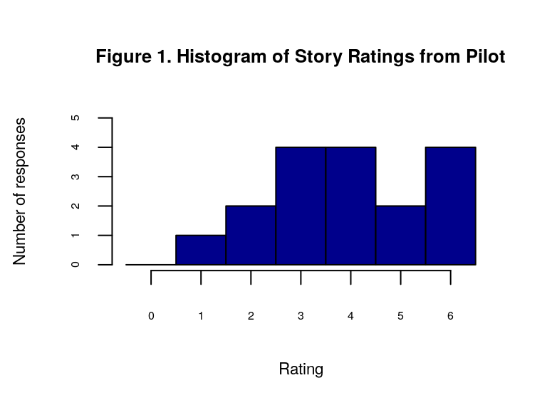

## 3.2. Experiment Data

### 3.2.1 Data Sources

For our main experiment, survey responses were sourced from three different environments:

1. Amazon Mechanical Turk with Masters qualification
2. Amazon Mechanical Turk without Masters qualification
3. Friends & Family (Facebook, LinkedIn, I School Slack)

All survey responses were returned to us via Qualtrics. We were able to distinguish which response belonged to which group thanks to requiring the Mechanical Turk workers to input a code generated by our survey after survey completion. We later joined the datasets together and assigned each participant to their respective group. `Table 1` shows the number of responses receveived from each group.

| Table 1. Responses by Source Group Source | Table 1. Responses by Source Group Count |
| --- | --- |
| Mturk Masters | 42 |
| Mturk Regulars | 298 |
| F&F | 179 |

### 3.2.2. Identifying Invalid Responses

`Figure 2` shows how many survey responses were dropped and for which reasons.

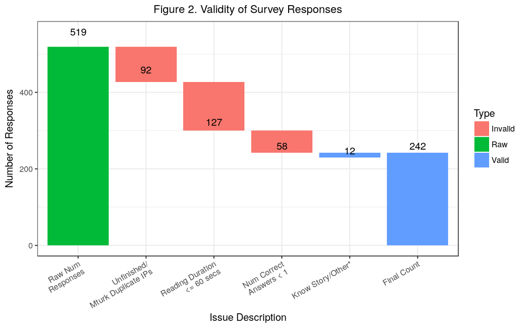

### 3.2.3. Balance Checks for Invalid Responses

There are three distinct groups in this experiment:

1. Control
2. Treatment - Low Rating
3. Treatment - High Rating

In this section, we will check if responses marked as invalid were fairly distributed across the above three groups.

Qualtrics allocated surverys at random order to the above three groups. As we can see from `Table 2` there was some slight inbalance as `Treat: Low` received a bit lower than fair share of responses. We’ll assume it’s due to random noise.

|  | Table 2. Qualtrics Treatment Group Assignment Control | Table 2. Qualtrics Treatment Group Assignment Treat: High | Table 2. Qualtrics Treatment Group Assignment Treat: Low |
| --- | --- | --- | --- |
| Responses | 178.00 | 179.00 | 162.00 |
| Percent | 0.34 | 0.34 | 0.31 |

As indicated in `Figure 2`, we dropped 92 responses because they either did not finish the entire survey or did not answer the main question. `Table 3` checks the distribution of these responses across treatment groups. The only issue that stands out is that an unproportionally low number of unfinished surveys were in the `Treat: Low` group, but it is consistent with the fact that Qualtrics allocation was not even.

|  | Table 3. Unfinished Surveys Balance Check Control | Table 3. Unfinished Surveys Balance Check Treat: High | Table 3. Unfinished Surveys Balance Check Treat: Low |
| --- | --- | --- | --- |
| Missing outcome | 4 | 4 | 6 |
| Not Finished | 25 | 28 | 17 |
| Duplicate IP | 3 | 1 | 4 |
| Valid | 146 | 146 | 135 |

After we drop the 92 responses, we exclude 185 cases that either spent less than 60 seconds on the survey or did not answer at least 1 reading comprehension question correctly. The distribution of responses across groups is consistent with the original allocation by Qualtrics (`Table 4`)

|  | Table 4. Valid Responses Balance Check Control | Table 4. Valid Responses Balance Check Treat: High | Table 4. Valid Responses Balance Check Treat: Low |
| --- | --- | --- | --- |
| Undertime/Failed RC | 60.00 | 64.00 | 61.00 |
| Valid | 86.00 | 82.00 | 74.00 |
| Percent | 0.36 | 0.34 | 0.31 |

The last check is to see how valid responses were distributed across source groups (`Table 5`). Interestingly enough, `Treat: Low` group has more responses in the `Friends and Family` group compared to `Treat: High` and `Control`. We do not have a strong hypothesis to explain this inconsistency and we will assume that it’s random.

|  | Table 5. Source Balance Check Control | Table 5. Source Balance Check Treat: High | Table 5. Source Balance Check Treat: Low |
| --- | --- | --- | --- |
| Mturk Masters | 13 | 10 | 9 |
| Mturk Regulars | 48 | 47 | 35 |
| F&F | 25 | 25 | 30 |

# 4. Experiment Outcome

Our final analysis sample consists of 242 valid responses. However, we will check if including invalid responses impacts the results.

## 4.1 Outcome Distribution

Before calculating ATE as a difference in average rating across treatment groups, we will check the distribution of this variable.

Responders had to rate the story on a scale from 1 to 6. We decided to use an even scale to force responders pick a side instead of providing a neutral response. Based on `Figure 3a` for `Control` group, average rating without any treatment was above 3.5 (expected average). This indicates that the story was slightly better than average.

`Treat High` group had the highest proportion of 5-star ratings, but it was not enough to increase the group’s average rating compared to the `Control` group. `Treat Low` group, on the other hand, had a lower average rating compared to the other two groups.

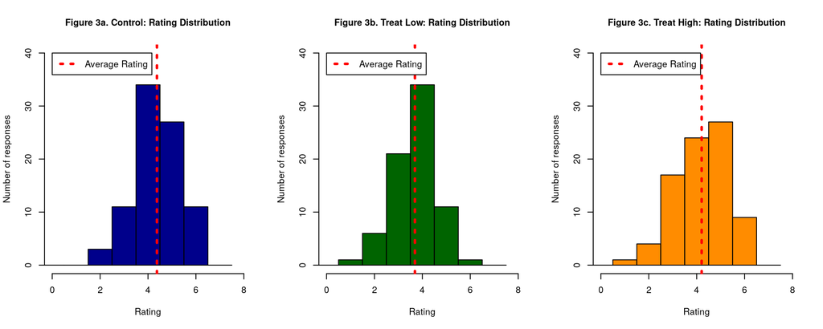

## 4.2 Average Treatment Effect

### 4.2.1 Manual Calculation

We calculated the effect of the treatment with two different methods. The first is with a standard estimated ATE calculation. The results can be seen in `Table 6`.

The average control rating was 4.37. The average low rating was 3.69. The average high rating was 4.21. As you can see, the largest effect (in absolute terms) was caused by the low rating treatment. Interestingly, the average high rating is slightly lower than the average control. These results suggest that users are significantly more influenced by lower reviews than high ones.

| Group | Table 6. Average Treatment Effect # of Subjects | Table 6. Average Treatment Effect % of Total Subjects | Table 6. Average Treatment Effect Treated Rating | Table 6. Average Treatment Effect AVG Rating | Table 6. Average Treatment Effect ATE |
| --- | --- | --- | --- | --- | --- |
| Control | 86 | 35.54 | NA | 4.37 |  |
| Treatment - Low Rating | 74 | 30.58 | 2/6 Stars | 3.69 | -0.68 |
| Treatment - High Rating | 82 | 33.88 | 5/6 Stars | 4.21 | -0.16 |

### 4.2.2 Regression Analysis

The second calculation method is with linear regression. Linear regression yields (`Table 7`) an estimated coefficient of -0.16 (robust std.error: 0.16) for the `Treat High` and -0.68 (robust std.error: 0.15) for the `Treat Low`. The Low group coefficient is highly statistically significant with a confidence interval of (-0.98, -0.39).

```
##
## Table 7. Regression Estimated ATE
## =================================================
##                          Dependent variable:
##                     -----------------------------
##                            Average Rating
##                         Valid Responses Only
## -------------------------------------------------
## Treat: High                    -0.165
##                                (0.164)
## Treat: Low                    -0.683***
##                                (0.152)
## Constant                      4.372***
##                                (0.107)
## -------------------------------------------------
## Observations                     242
## Residual Std. Error       1.013 (df = 239)
## =================================================
## Note:               *p<0.05; **p<0.01; ***p<0.001
```

## 4.2.3 Regression Analysis and Invalid Responses

Since we excluded a fair share of responses due to serious validity issues, we want to check if including them changes our results. `Table 8` compared outputs of 3 models:

1. Our main regression on 242 valid responses (same as `Table 7`)
2. Same model specification but with all 427 responses included
3. Model with all 427 responses and additional controls for invalid responses

```
##
## Table 8. Regression Estimated ATE
## ===================================================================================
##                                               Dependent variable:
##                              ------------------------------------------------------
##                                                  Average Rating
##                              Valid Responses Only  All Responses    All Responses
##                                      (1)                (2)              (3)
## -----------------------------------------------------------------------------------
## Treat: High                         -0.165             -0.041           -0.039
##                                    (0.164)            (0.130)          (0.131)
## Treat: Low                        -0.683***           -0.375**         -0.411**
##                                    (0.152)            (0.129)          (0.127)
## Finished in < 60 sec                                                    0.116
##                                                                        (0.120)
## Failed Reading Comprehension                                           -0.572**
##                                                                        (0.186)
## Constant                           4.372***           4.212***         4.253***
##                                    (0.107)            (0.088)          (0.097)
## -----------------------------------------------------------------------------------
## Observations                         242                427              427
## Residual Std. Error            1.013 (df = 239)   1.103 (df = 424) 1.090 (df = 422)
## ===================================================================================
## Note:                                                 *p<0.05; **p<0.01; ***p<0.001
```

Unfortunately, the results in `Table 8` indicate that:

- After including invalid responses the `Treat Low` effect is around 50% lower, but still statistically significant.
- Responders that failed all 3 reading comprehension questions had significantly lower average rating compared to other responders with coefficient -0.57 (0.19).

However, if we check `Table 9` below, the majority of responders that failed reading comprehension were from `MTurk Regulars` group. Therefore, we can suggest two hypothesis for the above results:

1. `MTurk Regulars` did not read the story carefully and, hence, did not have strong opinion on it. They then picked the score that was closer to the expected average rating
2. `MTurk Regulars` did not read the story at all (potentially bots) and picked the score that was closer to the expected average rating

Regardless of the explanations, the results are still consistent: the impact of Low ratings are statistically significant, while High ratings do not make people change their minds.

| Source | Table 9. Number of Responders That Failed All Reading Comprehension Questions Response Count Control | Table 9. Number of Responders That Failed All Reading Comprehension Questions Response Count Treat: High | Table 9. Number of Responders That Failed All Reading Comprehension Questions Response Count Treat: Low | Table 9. Number of Responders That Failed All Reading Comprehension Questions Average Rating Control | Table 9. Number of Responders That Failed All Reading Comprehension Questions Average Rating Treat: High | Table 9. Number of Responders That Failed All Reading Comprehension Questions Average Rating Treat: Low |
| --- | --- | --- | --- | --- | --- | --- |
| Mturk Masters | 2 | NA | NA | 3.00 | NA | NA |
| Mturk Regulars | 18 | 20 | 12 | 4.06 | 3.65 | 2.92 |
| F&F | 2 | 3 | 1 | 4.50 | 4.67 | 3.00 |

## 4.2.4 Source Group Results

Another interesting hypothesis that we can test is whether results differ by source group (`Table 10`).

```
##
## Table 10. Regression Estimated ATE by Source Group
## ====================================================================
##                                   Dependent variable:
##                     ------------------------------------------------
##                                      Average Rating
##                      Mturk Masters   Mturk Regulars        F&F
##                           (1)             (2)              (3)
## --------------------------------------------------------------------
## Treat: High              0.300           -0.285          -0.160
##                         (0.497)         (0.213)          (0.299)
## Treat: Low              -0.778         -1.004***         -0.187
##                         (0.464)         (0.226)          (0.231)
## Constant               4.000***         4.604***        4.120***
##                         (0.312)         (0.134)          (0.198)
## --------------------------------------------------------------------
## Observations              32              130              80
## Residual Std. Error 1.077 (df = 29) 1.035 (df = 127) 0.908 (df = 77)
## ====================================================================
## Note:                                  *p<0.05; **p<0.01; ***p<0.001
```

These results suggest that:

- In none of the three groups, the `High` rating impacted people’s opinions about the story (as compared to the `Control` group rating)
- In `MTurk` groups, the `Low` rating was 0.8 to 1 lower than the average `Control` group score. However, the effect estimate for the `Masters` group is not statistically significant mostly due to low sample size
- For the `F&F` group, neither of the treatments made a difference. Their average ratings were statstically indistinguishable across all treatment and control groups

It is hard to explain these results without knowing `MTurk` responders audience. However, we can speculate with high confidence that `Friends & Family` audience has higher education and employment levels than people who earn money on `MTurk`. That might influence how they read and perceive the story. And it might be that they are much better at forming and staying with their opinions.

# 5. Conclusion

After conducting a survey with the aim of measuring the impact of high and low numerical ratings on a reader’s perception of a short story, we conclude that the evidence suggests readers are in fact influenced by negative reviews but not positive ones.

How do the results of this experiment generalize to other industries and domains? In today’s society, ratings and reviews seem to be everywhere. Most prominently, they can be found in the commerical sector on sites such as Amazon, Google, or Yelp. While a short story is not directly comparable to a movie or restaurant experience, we believe that the pyschological impact of seeing a review prior to the targeted event persists across these experiences.

From a business perspective, the takeaway of this experiment is clear: avoid negative reviews. This is not particularly shocking as many might consider it common sense that a positive reputation is likely to lead to more customers. From an individual perspective, this experiment suggests that we can be unknowingly biased by negative reviews which is something to keep in mind while perusing Amazon for a new product or searching Yelp for your next meal.